# stochastic_two_group_model

#### Infectivity dependent transmission

```python
import time

start = time.time()
# using the default parameters in the paper by Nandi and Allen
time_hist, state_hist = gillespie_algo(100, X_0 = [900, 100, 0, 1, 0, 0], rates = [0.2, 5, 0.2, 5, 0.5, 0.2])
end = time.time()
print("Completed in: " +str(end - start) + " seconds")
print(time_hist[-2])
```

```
Completed in: 0.10866665840148926 seconds
35.98868346123634
```

```python
S_1 = [item[0] for item in state_hist]
S_2 = [item[1] for item in state_hist]
I_1 = [item[2] for item in state_hist]
I_2 = [item[3] for item in state_hist]
R_1 = [item[4] for item in state_hist]
R_2 = [item[5] for item in state_hist]
```

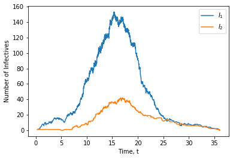

```python
plt.plot(time_hist, I_1)
plt.plot(time_hist, I_2)
plt.legend(["$I_1$", "$I_2$"])
plt.ylabel("Number of Infectives")
plt.xlabel("Time, t")
plt.show()
```

#### Host susceptibility dependent transmission

```python
import time

start = time.time()
# using the default parameters in the paper by Nandi and Allen
time_hist, state_hist = gillespie_algo(100, X_0 = [5000, 500, 0, 1, 0, 0], rates = [0.2, 0.2, 5, 5, 0.5, 0.2])
end = time.time()
print("Completed in: " +str(end - start) + " seconds")
print(time_hist[-2])
```

```
Completed in: 0.14583992958068848 seconds
48.63968526050156
```

```python
S_1 = [item[0] for item in state_hist]
S_2 = [item[1] for item in state_hist]
I_1 = [item[2] for item in state_hist]
I_2 = [item[3] for item in state_hist]
R_1 = [item[4] for item in state_hist]
R_2 = [item[5] for item in state_hist]
```

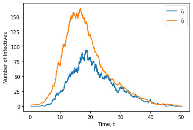

```python
plt.plot(time_hist, I_1)
plt.plot(time_hist, I_2)
plt.legend(["$I_1$", "$I_2$"])
plt.ylabel("Number of Infectives")
plt.xlabel("Time, t")
plt.show()
```

### Simulations - Varying $\mathcal{R}_0$ and transmission dependance

In this section, we extend the model presented in [1] by considering different types of population interactions, along with different $\mathcal{R}_0$ values. We start by considering the infected/susceptible dependent transmission models above, however altering the the parameters so that the $\mathcal{R}_0$ lie closer to 1 and then below one.

#### Simulations - $\mathcal{R}_0 = 1.2$, driven by infectivity of host.

```python
import time
R_0 = 1.2
B_1 = 0.2
B_2 = 2*(R_0 - 2*B_1*0.9)


start = time.time()
# using the default parameters in the paper by Nandi and Allen
time_hist, state_hist = gillespie_algo(100, X_0 = [900, 100, 0, 1, 0, 0], rates = [B_1, B_2, B_1, B_2, 0.5, 0.2])
end = time.time()
print("Completed in: " +str(end - start) + " seconds")
print(time_hist[-2])
```

```
Completed in: 0.04284811019897461 seconds
33.65761900350261
```

```python
S_1 = [item[0] for item in state_hist]
S_2 = [item[1] for item in state_hist]
I_1 = [item[2] for item in state_hist]
I_2 = [item[3] for item in state_hist]
R_1 = [item[4] for item in state_hist]
R_2 = [item[5] for item in state_hist]
```

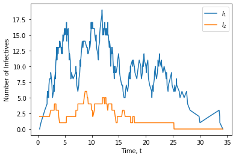

```python
plt.plot(time_hist, I_1, drawstyle = "steps-pre")
plt.plot(time_hist, I_2, drawstyle = "steps-pre")
plt.legend(["$I_1$", "$I_2$"])
plt.ylabel("Number of Infectives")
plt.xlabel("Time, t")
plt.show()
```

```python
B_2
```

```
1.6799999999999997
```

```python
import time
R_0 = 0.85
B_1 = 0.2
B_2 = 2*(R_0 - 2*B_1*0.9)


start = time.time()
# using the default parameters in the paper by Nandi and Allen
time_hist, state_hist = gillespie_algo(100, X_0 = [900, 100, 0, 1, 0, 0], rates = [B_1, B_1, B_2, B_2, 0.5, 0.2])
end = time.time()
print("Completed in: " +str(end - start) + " seconds")
print(time_hist[-2])
```

```
Completed in: 0.0029594898223876953 seconds
24.916543550034103
```

```python
S_1 = [item[0] for item in state_hist]
S_2 = [item[1] for item in state_hist]
I_1 = [item[2] for item in state_hist]
I_2 = [item[3] for item in state_hist]
R_1 = [item[4] for item in state_hist]
R_2 = [item[5] for item in state_hist]
```

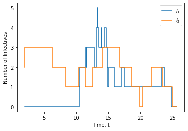

```python
plt.plot(time_hist, I_1, drawstyle = "steps-pre")
plt.plot(time_hist, I_2, drawstyle = "steps-pre")
plt.legend(["$I_1$", "$I_2$"])
plt.ylabel("Number of Infectives")
plt.xlabel("Time, t")
plt.show()
```

### Strong within-group infections

We alter the previously given models to consider a population which is susceptible to a disease. In this section, we consider a population of two groups, where there is strong transmission of the disease within the groups, and relatively weak transmission of the disease between groups (that is the groups do not mix often in comparison to their within group mixing). To model such a scenario, we consider the contact rates $\beta_{jk}$; for the within-group contact rates to be stronger, we require that $\beta_{11} >> \beta_{21}$ and $\beta_{22} >> \beta_{12}$.

#### Simulation: $\mathcal{R}_0 = 2.5$

```python
import time
# R_0 = 2.3
# B_1 = 0.2
# B_2 = 2*(R_0 - 2*B_1*0.9)

B_11 = 0.6
B_12 = 0.05
B_21 = 0.05
B_22 = 0.4
N_1 = 500
N_2 = 500
N = N_1 + N_2
y_1 = 0.2
y_2 = 0.2

print("R_0 = " + str(  (1/(2*N)) * ((B_11*N_1)/(y_1) + (B_22*N_2)/(y_2) + math.sqrt(((B_11*N_1)/(y_1) + (B_22*N_2)/(y_2))**2 - 4*N_1*N_2*y_1*y_2*(B_11*B_22 - B_12*B_21))    ) ))

start = time.time()
# using the default parameters in the paper by Nandi and Allen
time_hist, state_hist = gillespie_algo(100, X_0 = [500, 500, 0, 1, 0, 0], rates = [B_11, B_12, B_21, B_22, 0.2, 0.2])
end = time.time()
print("Completed in: " +str(end - start) + " seconds")
print(time_hist[-2])
```

```
R_0 = 2.4990496387253787
Completed in: 0.005991935729980469 seconds
57.441785514546304
```

```python
S_1 = [item[0] for item in state_hist]
S_2 = [item[1] for item in state_hist]
I_1 = [item[2] for item in state_hist]
I_2 = [item[3] for item in state_hist]
R_1 = [item[4] for item in state_hist]
R_2 = [item[5] for item in state_hist]
```

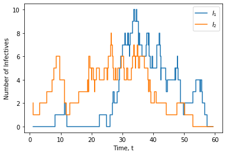

```python
plt.plot(time_hist, I_1, drawstyle = "steps-pre")
plt.plot(time_hist, I_2, drawstyle = "steps-pre")
plt.legend(["$I_1$", "$I_2$"])
plt.ylabel("Number of Infectives")
plt.xlabel("Time, t")
plt.show()
```

```python
import time
# R_0 = 2.3
# B_1 = 0.2
# B_2 = 2*(R_0 - 2*B_1*0.9)

B_11 = 0.8
B_12 = 0.05
B_21 = 0.05
B_22 = 0.7
N_1 = 500
N_2 = 500
N = N_1 + N_2
y_1 = 0.5
y_2 = 0.5

print("R_0 = " + str(  (1/(2*N)) * ((B_11*N_1)/(y_1) + (B_22*N_2)/(y_2) + math.sqrt(((B_11*N_1)/(y_1) + (B_22*N_2)/(y_2))**2 - 4*N_1*N_2*y_1*y_2*(B_11*B_22 - B_12*B_21))    ) ))

start = time.time()
# using the default parameters in the paper by Nandi and Allen
time_hist, state_hist = gillespie_algo(100, X_0 = [500, 500, 0, 1, 0, 0], rates = [B_11, B_12, B_21, B_22, y_1, y_2])
end = time.time()
print("Completed in: " +str(end - start) + " seconds")
print("Total waitig time: " + str(time_hist[-2]))
```

```
R_0 = 1.4763995112883819
Completed in: 0.0009970664978027344 seconds
Total waitig time: 11.485203621780744
```

```python
S_1 = [item[0] for item in state_hist]
S_2 = [item[1] for item in state_hist]
I_1 = [item[2] for item in state_hist]
I_2 = [item[3] for item in state_hist]
R_1 = [item[4] for item in state_hist]
R_2 = [item[5] for item in state_hist]
```

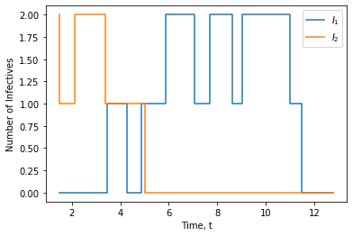

```python
plt.plot(time_hist, I_1, drawstyle = "steps-pre")
plt.plot(time_hist, I_2, drawstyle = "steps-pre")
plt.legend(["$I_1$", "$I_2$"])
plt.ylabel("Number of Infectives")
plt.xlabel("Time, t")
plt.show()
```

#### Simulation: $\mathcal{R}_0 = 0.9$

```python
import time
# R_0 = 2.3
# B_1 = 0.2
# B_2 = 2*(R_0 - 2*B_1*0.9)

B_11 = 0.5
B_12 = 0.05
B_21 = 0.05
B_22 = 0.45
N_1 = 500
N_2 = 500
N = N_1 + N_2
y_1 = 0.5
y_2 = 0.5

print("R_0 = " + str(  (1/(2*N)) * ((B_11*N_1)/(y_1) + (B_22*N_2)/(y_2) + math.sqrt(((B_11*N_1)/(y_1) + (B_22*N_2)/(y_2))**2 - 4*N_1*N_2*y_1*y_2*(B_11*B_22 - B_12*B_21))    ) ))

start = time.time()
# using the default parameters in the paper by Nandi and Allen
time_hist, state_hist = gillespie_algo(100, X_0 = [500, 500, 0, 1, 0, 0], rates = [B_11, B_12, B_21, B_22, y_1, y_2])
end = time.time()
print("Completed in: " +str(end - start) + " seconds")
print("Total waitig time: " + str(time_hist[-2]))
```

```
R_0 = 0.9351290579826491
Completed in: 0.0 seconds
Total waitig time: 1.072494798380558
```

```python
S_1 = [item[0] for item in state_hist]
S_2 = [item[1] for item in state_hist]
I_1 = [item[2] for item in state_hist]
I_2 = [item[3] for item in state_hist]
R_1 = [item[4] for item in state_hist]
R_2 = [item[5] for item in state_hist]
```

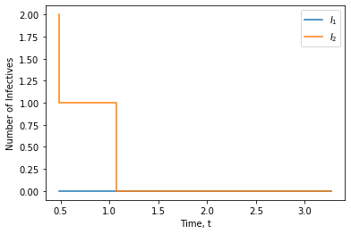

```python
plt.plot(time_hist, I_1, drawstyle = "steps-pre")
plt.plot(time_hist, I_2, drawstyle = "steps-pre")
plt.legend(["$I_1$", "$I_2$"])
plt.ylabel("Number of Infectives")
plt.xlabel("Time, t")
plt.show()
```